# HAYRETTİN İLBEY GÜNGÖR 2018402183

# IE 360 HOMEWORK1

In this homework, I will try to find the factors that affect the income generated in the tourism sector in Turkey and check the correlations between them. In order to do that, i will use these monthly data between 2008/01 and 2021/12: Tourists numbers in Turkey Total travel income of Turkey(Million USD) Google Trends data for "Türkiye"(worldwide) Google Trends data for "Otel" (in Turkey)

## 1)Installing required libraries

```r
install.packages('openxlsx')
install.packages('ggplot2')
install.packages('data.table')
install.packages('skimr')
install.packages('GGally')
install.packages('ggcorrplot')
install.packages('forecast')
install.packages('lubridate')
install.packages('zoo')
```

```r
require(openxlsx)
require(ggplot2)
require(data.table)
require(skimr)
require(GGally)
require(ggcorrplot)
require(forecast)
library(lubridate)
library(zoo)
```

```r
numberoftourists=read.xlsx('excelfiles/toplamziyaretcisayisi.xlsx')
head(numberoftourists,24)
tail(numberoftourists,24)
summary(numberoftourists$Amount)
str(numberoftourists)
```

A data.frame: 24 × 2

|  | Tarih <chr> | Amount <dbl> |
| --- | --- | --- |
| 1 | 2008-01 | 919539 |
| 2 | 2008-02 | 858751 |
| 3 | 2008-03 | 1221568 |
| 4 | 2008-04 | 1411495 |
| 5 | 2008-05 | 2509997 |
| 6 | 2008-06 | 2902948 |
| 7 | 2008-07 | 3545795 |
| 8 | 2008-08 | 4450081 |
| 9 | 2008-09 | 3286998 |
| 10 | 2008-10 | 2839973 |
| 11 | 2008-11 | 1444305 |
| 12 | 2008-12 | 1039674 |
| 13 | 2009-01 | 906602 |
| 14 | 2009-02 | 857114 |
| 15 | 2009-03 | 1179459 |
| 16 | 2009-04 | 1564694 |
| 17 | 2009-05 | 2416640 |
| 18 | 2009-06 | 2999541 |
| 19 | 2009-07 | 3615548 |
| 20 | 2009-08 | 4605083 |
| 21 | 2009-09 | 3349978 |
| 22 | 2009-10 | 3115112 |
| 23 | 2009-11 | 1581734 |
| 24 | 2009-12 | 1156472 |

A data.frame: 24 × 2

|  | Tarih <chr> | Amount <dbl> |
| --- | --- | --- |
| 145 | 2020-01 | 2065570 |
| 146 | 2020-02 | 1664208 |
| 147 | 2020-03 | 906067 |
| 148 | 2020-04 | 50630 |
| 149 | 2020-05 | 51588 |
| 150 | 2020-06 | 128861 |
| 151 | 2020-07 | 529990 |
| 152 | 2020-08 | 1712380 |
| 153 | 2020-09 | 2187683 |
| 154 | 2020-10 | 2000557 |
| 155 | 2020-11 | 960402 |
| 156 | 2020-12 | 681408 |
| 157 | 2021-01 | 570447 |
| 158 | 2021-02 | 494337 |
| 159 | 2021-03 | 761443 |
| 160 | 2021-04 | 895342 |
| 161 | 2021-05 | 757518 |
| 162 | 2021-06 | 1491955 |
| 163 | 2021-07 | 3231555 |
| 164 | 2021-08 | 4578265 |
| 165 | 2021-09 | 3648131 |
| 166 | 2021-10 | 3777732 |
| 167 | 2021-11 | 2080510 |
| 168 | 2021-12 | 1652786 |

```
   Min. 1st Qu.  Median    Mean 3rd Qu.    Max.
  50630 1342116 2088868 2548310 3644266 7018257
```

```
'data.frame':	168 obs. of  2 variables:
 $ Tarih : chr  "2008-01" "2008-02" "2008-03" "2008-04" ...
 $ Amount: num  919539 858751 1221568 1411495 2509997 ...
```

## 2) Gathering data and Visualization of them

[figure not shown]

```r
ggplot(numberoftourists ,aes(Tarih,Amount, group = 1)) + geom_point() + geom_line(data = numberoftourists, color="orange", linetype = "solid") +labs(title = "Number of Tourists in Turkey(Monthly)", x = "Date",y = "Number of tourists",subtitle = "Jan-2018 to Dec-2021")
```

```r
totaltravelincome=read.xlsx('excelfiles/toplamseyahatgeliri.xlsx')
str(totaltravelincome)
```

```
'data.frame':	168 obs. of  2 variables:
 $ Tarih : chr  "2008-01" "2008-02" "2008-03" "2008-04" ...
 $ Income: num  917 827 1128 1128 1837 ...
```

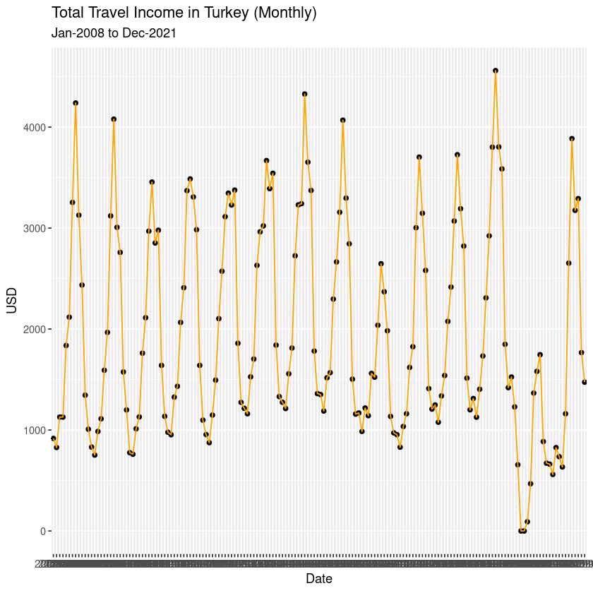

```r
ggplot(totaltravelincome ,aes(Tarih,Income, group = 1)) + geom_point() + geom_line(data = totaltravelincome, color="orange", linetype = "solid") + labs(title = "Total Travel Income in Turkey (Monthly)", x = "Date",y = "USD",subtitle = "Jan-2008 to Dec-2021")
```

```r
searchofTurkey1=read.csv('excelfiles/searchforturkey.csv')
str(searchofTurkey1)
```

```
'data.frame':	168 obs. of  2 variables:
 $ Date  : chr  "2008-01" "2008-02" "2008-03" "2008-04" ...
 $ Search: int  44 43 48 57 66 86 83 66 49 36 ...
```

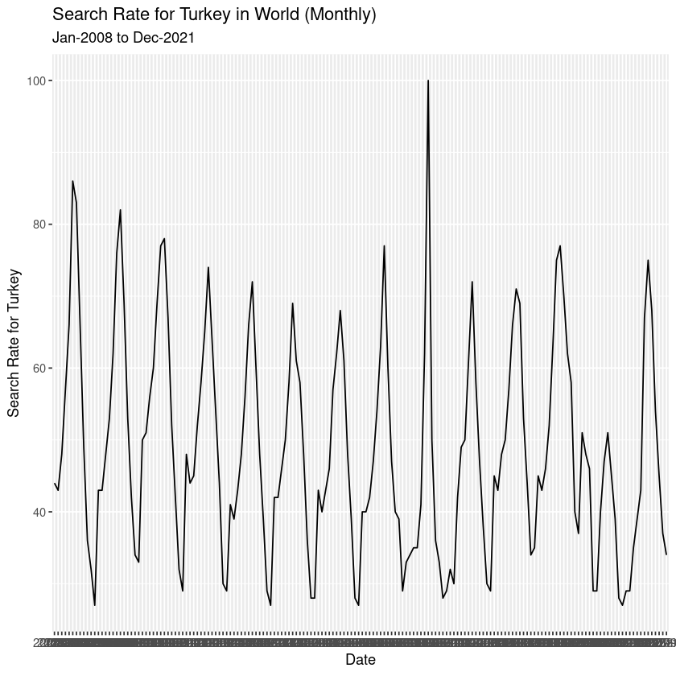

```r
ggplot(searchofTurkey1 ,aes(x=Date,y=Search, group = 1)) + geom_line() + labs(title = "Search Rate for Turkey in World (Monthly)", x = "Date",y = "Search Rate for Turkey",subtitle = "Jan-2008 to Dec-2021")
```

```r
searchforhotels=read.xlsx('excelfiles/searchforhotels.xlsx')
str(searchforhotels)
```

```
'data.frame':	168 obs. of  2 variables:
 $ Date          : chr  "2008-01" "2008-02" "2008-03" "2008-04" ...
 $ SearchofHotels: num  16 16 24 29 34 48 62 46 29 17 ...
```

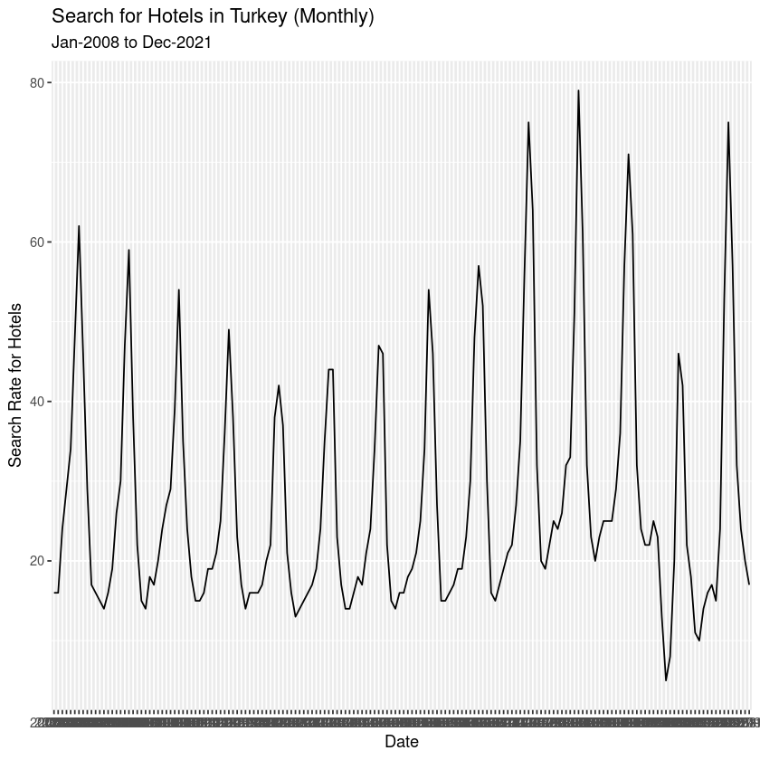

```r
ggplot(searchforhotels ,aes(x=Date,y=SearchofHotels, group = 1)) + geom_line() + labs(title = "Search for Hotels in Turkey (Monthly)", x = "Date",y = "Search Rate for Hotels",subtitle = "Jan-2008 to Dec-2021")
```

## 3) Visual Comparison of "Search for Hotel in Turkey" Data and the Other Data

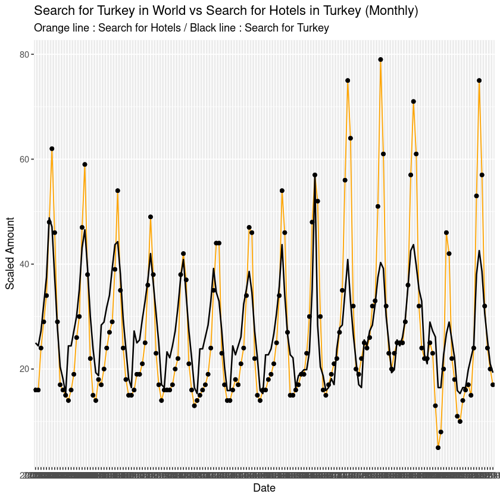

```r
scaler= mean(searchforhotels$SearchofHotels)/mean(searchofTurkey1$Search)
ggplot(searchforhotels ,aes(Date,SearchofHotels, group = 1)) + geom_point() + geom_line(data = searchforhotels, color="orange", linetype = "solid") + geom_point() + geom_line(data = searchofTurkey1,mapping=aes(x=Date,y=Search*scaler),size=0.7,colour="black") + labs(title = "Search for Turkey in World vs Search for Hotels in Turkey (Monthly)", x = "Date",y = "Scaled Amount",subtitle = "Orange line : Search for Hotels / Black line : Search for Turkey")
```

There is strong visual pattern between Search for hotels and search for Turkey. It seems like there is a positive correlation between them.

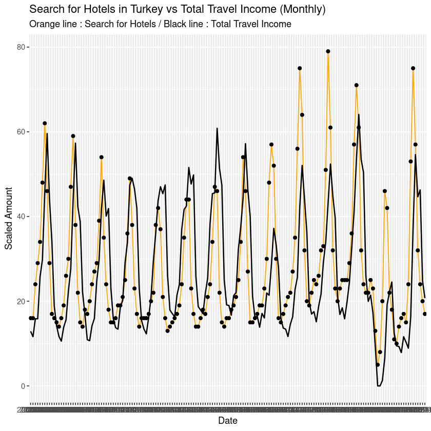

```r
scaler= mean(searchforhotels$SearchofHotels)/mean(totaltravelincome$Income)
ggplot(searchforhotels ,aes(Date,SearchofHotels, group = 1)) + geom_point() + geom_line(data = searchforhotels, color="orange", linetype = "solid") + geom_point() + geom_line(data = totaltravelincome,mapping=aes(x=Tarih,y=Income*scaler),size=0.7,colour="black") + labs(title = "Search for Hotels in Turkey vs Total Travel Income (Monthly)", x = "Date",y = "Scaled Amount",subtitle = "Orange line : Search for Hotels / Black line : Total Travel Income")
```

There is strong visual pattern between Search for hotels and total travel income. It seems like there is a positive correlation between them.

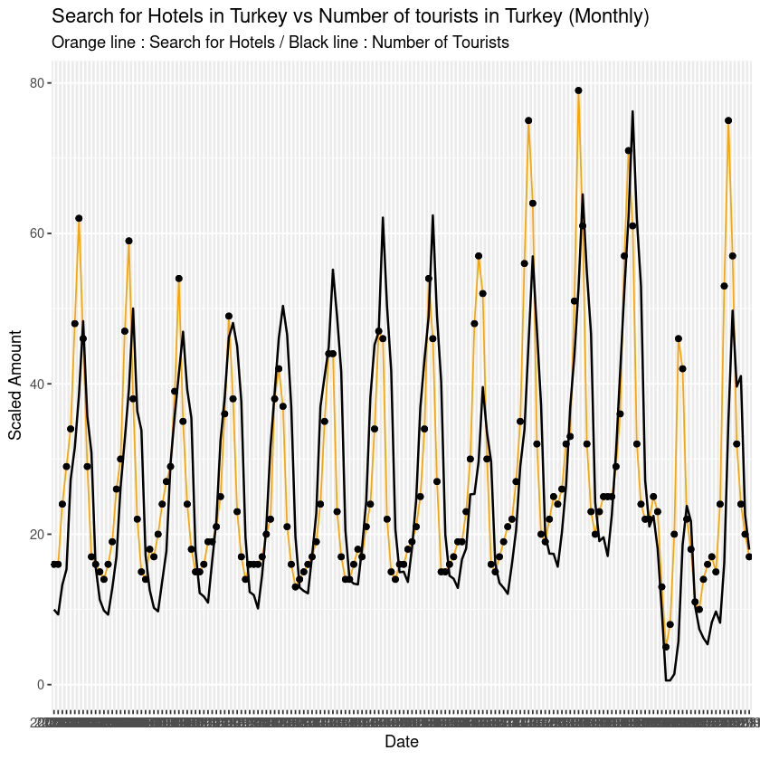

```r
scaler= mean(searchforhotels$SearchofHotels)/mean(numberoftourists$Amount)
ggplot(searchforhotels ,aes(Date,SearchofHotels, group = 1)) + geom_point() + geom_line(data = searchforhotels, color="orange", linetype = "solid") + geom_point() + geom_line(data = numberoftourists,mapping=aes(x=Tarih,y=Amount*scaler),size=0.7,colour="black") + labs(title = "Search for Hotels in Turkey vs Number of tourists in Turkey (Monthly)", x = "Date",y = "Scaled Amount",subtitle = "Orange line : Search for Hotels / Black line : Number of Tourists")
```

There is strong visual pattern between Search for hotels and number of tourists. It seems like there is a positive correlation between them.

## 4) Comment on ggpair table

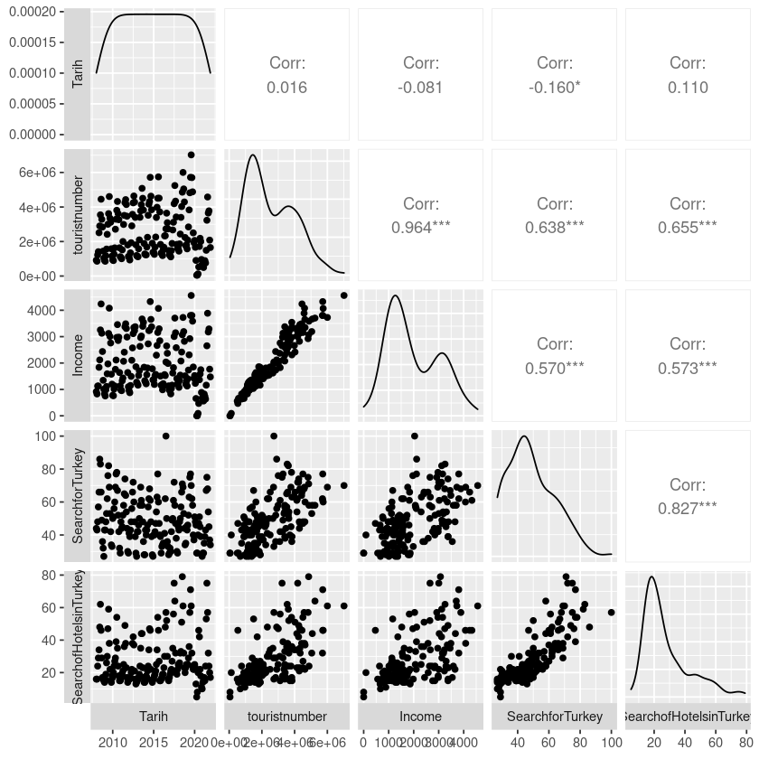

```r
alldata = read.xlsx('excelfiles/alldata.xlsx')
alldata$Tarih = paste0(alldata$Tarih, rep("-01",length(alldata$Tarih)))
alldata$Tarih = as.Date(alldata$Tarih)
alldata[,1]=as.Date(alldata[,1])
ggpairs(alldata,switch='both')
```

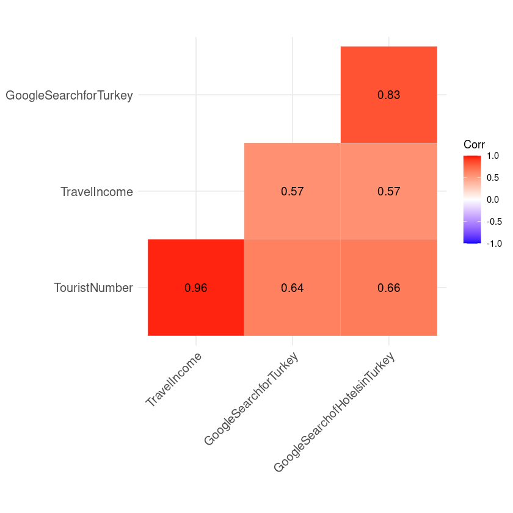

```r
cor_data=data.frame(cbind(alldata$touristnumber,alldata$Income,alldata$SearchforTurkey,alldata$SearchofHotelsinTurkey))
colnames(cor_data)=c("TouristNumber", "TravelIncome", "GoogleSearchforTurkey","GoogleSearchofHotelsinTurkey")

ggcorrplot(cor(cor_data),
           hc.order = TRUE,
           type = "lower",
           lab = TRUE)
```

When the ggpair and ggcorplot tables are examined, it seems that all of the categories are correlated with the search of "Hotel" in Turkey. In order to explain deeply, i will try to clarify all relations independently.

Search for Turkey in World vs Search for Hotels in Turkey: Their correlation coefficient is 0.827 which is the highest coefficient among them. Scatter plot of them shows that the seasonality effects both of them in a similar way. It is reasonable beacuse Turkey is a country where people would take vacation in the summer generally. When people search "Turkey" in google and decide to come here, they search hotels to stay during their vacation.

Total Travel Income vs Search for Hotels in Turkey: Correlation coefficient between total travel income and search for "Hotel" in Turkey is 0.573. Despite the fact that it is a strong correlation, it is the lowest correlation coefficent among them. When we look at the comparison scatter plot, the pattern of total travel income seems to have shifted a little more to the right from the pattern of search data for "Hotel". The reason behind this may be that people actually come to Turkey on holiday after a while after making their search.

Number of Tourists in Turkey vs Search for Hotels in Turkey: The correlation coefficient between them is 0.655. It is stronger relation than Total Travel Income vs Search for Hotels in Turkey. However their pattern looks similar to Income vs Search for Hotels. The reason that makes their relation stronger than the Income vs Search for Hotels may be that everyone who come to Turkey need to find a place to stay, but they do not have to spend a lot of money.